# Relationship between Chemical Exposure, Demographics, and Social Stressors

Elise Hickman

# 1 Set up workspace

```r
# Clear global environment
rm(list=ls())

# Load packages
library(tidyverse) # for data organization and manipulation
library(janitor) # for data cleaning
library(openxlsx) # for importing and exporting files
library(Hmisc) # for correlation analysis
library(rstatix) # for Dunn's test
library(FSA) # package that contains Dunn test function
library(ggpubr) # for graphing
library(factoextra) # for k-means clustering
library(NbClust) # for k-means clustering
library(patchwork) # for graphing
library(pheatmap) # for heatmap
library(rcartocolor) # for graphing
library(table1) # for demographic comparisons
select <- dplyr::select
rename <- dplyr::rename

library(ggpmisc) # for graphing
library(ggh4x) # for graphing


# Set theme
theme_set(theme_bw())

# Set working directory
setwd("/Users/ehickman/Library/CloudStorage/OneDrive-UniversityofNorthCarolinaatChapelHill/Rager_Lab/Projects/2023/BEE_Wristband_Project/4_Analyses/1_CurrentAnalyses/3_ChemicalDemoSSAnalysis")
```

# 2 Import data

For this and following analyses, the key data frames are:

- `wb_log2`: chemical data, log2 transformed
- `demo`: demographic data
- `ss_data`: social stressor data
- `chemical_key`: chemical information (classes, names)

```r
# Import and log2-transform chemical data (to match other analysis and allow for closer to normality for ANCOVA)
pseudolog <- function(x) log2(x+1)

wb_log2 <- read.xlsx("1_InputData/ChemicalData_Filtered_Imp_TW.xlsx") %>%
  mutate(across(where(is.numeric), pseudolog))

# Import demographic and social stressor data
demo <- read.xlsx("1_InputData/Demographic_Data_Cleaned.xlsx") %>%
  mutate(S_ID = as.character(S_ID))

ss_data <- read.xlsx("1_InputData/SS_Data_Cleaned.xlsx") %>%
  mutate(S_ID = as.character(S_ID))

# Import and clean chemical information
chemical_key <- read.xlsx("1_InputData/Minimum Detection Levels.xlsx", colNames = FALSE) %>%
  t() %>% as.data.frame() %>%
  remove_rownames() %>% # R had assigned unneeded row names
  row_to_names(1) %>% # Add column names
  na.omit() %>% # Some of the rows were completely empty
  dplyr::rename("chemical" = "Name", "mdl" = "MDL (ng/g)", "class_chemical" = "Variable Name", "class" = "Class") %>%
  select(-mdl)
```

# 3 Chemical exposure + demographics

Prior to analyzing the data, race will be collapsed into white and non-white, and we will join chemical data to demographic data.

```r
chem_demo <- left_join(wb_log2, demo, by = "S_ID") %>%
  mutate(race_forstats = case_when(pc_race_cleaned == "White" ~ "White",
                                   .default = "Non-White"))
```

## 3.1 Variable by variable

### 3.1.1 Age

```r
# Run correlation analysis
age_correlation_spearman <- chem_demo %>%
  select(where(is.numeric)) %>%
  select(-c(child_age_months, child_gest_age_birth, yrs_with_part)) %>%
  as.matrix() %>%
  rcorr(type = "spearman")

# Extract R values
age_corr_spearman_R <- age_correlation_spearman[[1]] %>%
  as.data.frame() %>%
  rownames_to_column(var = 'var1') %>%
  gather(var2, value, -var1) %>%
  filter(var1 == "mat_age_birth") %>%
  filter(var2 != "mat_age_birth") %>%
  unite(var1_var2, var1, var2, remove = FALSE) %>%
  rename("r" = "value")

# Extract p values
age_corr_spearman_p <- age_correlation_spearman[[3]] %>%
  as.data.frame() %>%
  rownames_to_column(var = 'var1') %>%
  gather(var2, value, -var1) %>%
  filter(var1 == "mat_age_birth") %>%
  filter(var2 != "mat_age_birth") %>%
  unite(var1_var2, var1, var2, remove = TRUE) %>%
  rename("p" = "value")

# Combine R and p values
age_correlation_spearman <- left_join(age_corr_spearman_R, age_corr_spearman_p, by = "var1_var2") %>%
  mutate(padj = p.adjust(p, method = "BH")) %>%
  mutate(Rsq = r * r) %>%
  relocate(Rsq, .after = "r")

# How many correlations have |R| > 0.6 and p < 0.05?
nrow(age_correlation_spearman %>% filter(abs(r) >= 0.6 & p < 0.05))
```

```
## [1] 0
```

```r
# Clean data frame for merging with all results later
age_correlation_spearman_cleaned <- age_correlation_spearman %>%
  rename("R_age" = "r", "pval_age" = "p", "padj_age" = "padj", "class_chemical" = "var2") %>%
  select(c(class_chemical, R_age, pval_age, padj_age))
```

### 3.1.2 Years with partner

Note - because there is missing data in this variable, it will not be included in the ANCOVA analysis below.

```r
# How many subjects have data?
nrow(chem_demo %>% select(yrs_with_part) %>% na.omit())
```

```
## [1] 78
```

```r
# Run correlation analysis
part_correlation_spearman <- chem_demo %>%
  select(where(is.numeric)) %>%
  select(-c(child_age_months, child_gest_age_birth, mat_age_birth)) %>%
  as.matrix() %>%
  rcorr(type = "spearman")

# Extract R values
part_corr_spearman_R <- part_correlation_spearman[[1]] %>%
  as.data.frame() %>%
  rownames_to_column(var = 'var1') %>%
  gather(var2, value, -var1) %>%
  filter(var1 == "yrs_with_part") %>%
  filter(var2 != "yrs_with_part") %>%
  unite(var1_var2, var1, var2, remove = FALSE) %>%
  rename("r" = "value")

# Extract p values
part_corr_spearman_p <- part_correlation_spearman[[3]] %>%
  as.data.frame() %>%
  rownames_to_column(var = 'var1') %>%
  gather(var2, value, -var1) %>%
  filter(var1 == "yrs_with_part") %>%
  filter(var2 != "yrs_with_part") %>%
  unite(var1_var2, var1, var2, remove = TRUE) %>%
  rename("p" = "value")

# Combine R and p values
part_correlation_spearman <- left_join(part_corr_spearman_R, part_corr_spearman_p, by = "var1_var2") %>%
  mutate(padj = p.adjust(p, method = "BH")) %>%
  mutate(Rsq = r * r) %>%
  relocate(Rsq, .after = "r")

# Clean data frame for merging with all results later
part_correlation_spearman_cleaned <- part_correlation_spearman %>%
  rename("R_part" = "r", "pval_part" = "p", "padj_part" = "padj", "class_chemical" = "var2") %>%
  select(c(class_chemical, R_part, pval_part, padj_part))

# How many correlations have |R| > 0.6 and p < 0.05?
nrow(part_correlation_spearman %>% filter(abs(r) >= 0.6 & p < 0.05))
```

```
## [1] 0
```

### 3.1.3 Race

```r
# Create a list of column names (chemicals) to run the analysis on
endpoints <- colnames(chem_demo %>% select(c(alkylOPE_2IPPDPP:Phthal_TOTM)))

# Create data frame to store results
race_wilcoxres <- data.frame()

# Run for loop
for (i in 1:length(endpoints)) {

  # Assign a name to the endpoint variable.
  endpoint <- endpoints[i]

  # Run wilcox test and store in results data frame.
  res <- wilcox.test(as.formula(paste0(endpoint, "~ race_forstats", sep = "")),
                     data = chem_demo)

  res_df <- data.frame(res$p.value) %>%
    rename("pval" = "res.p.value") %>%
    mutate("class_chemical" = endpoint)

  race_wilcoxres <- rbind(race_wilcoxres, res_df)
}

# Clean data frame
race_wilcoxres <- race_wilcoxres %>%
  relocate(class_chemical, .before = pval) %>%
  mutate(padj = p.adjust(pval, method = "BH")) %>%
  rename("pval_race" = "pval", "padj_race" = "padj")

# How many chemicals with padj < 0.1?
nrow(race_wilcoxres %>% filter(padj_race < 0.1))
```

```
## [1] 7
```

### 3.1.4 Latino/non-latino

```r
# Create a list of column names (chemicals) to run the analysis on
endpoints <- colnames(chem_demo %>% select(c(alkylOPE_2IPPDPP:Phthal_TOTM)))

# Create data frame to store results
latino_wilcoxres <- data.frame()

# Run for loop
for (i in 1:length(endpoints)) {

  # Assign a name to the endpoint variable.
  endpoint <- endpoints[i]

  # Run wilcox test and store in results data frame.
  res <- wilcox.test(as.formula(paste0(endpoint, "~ pc_latino_hispanic", sep = "")),
                     data = chem_demo)

  res_df <- data.frame(res$p.value) %>%
    rename("pval" = "res.p.value") %>%
    mutate("class_chemical" = endpoint)

  latino_wilcoxres <- rbind(latino_wilcoxres, res_df)
}

# Clean data frame
latino_wilcoxres <- latino_wilcoxres %>%
  relocate(class_chemical, .before = pval) %>%
  mutate(padj = p.adjust(pval, method = "BH")) %>%
  rename("pval_lat" = "pval", "padj_lat" = "padj")
```

### 3.1.5 Education level

```r
# Run Kruskal Wallis Test
edu_kruskal_res <- chem_demo %>%
  select(c(alkylOPE_2IPPDPP:Phthal_TOTM, pc_ed)) %>%
  pivot_longer(!pc_ed, names_to = "Variable", values_to = "Value") %>%
  group_by(Variable) %>%
  do(tidy(kruskal.test(x = .$Value, g = .$pc_ed))) %>%
  dplyr::select(c(Variable, p.value))

# Add p-adjustment
edu_kruskal_res$padj = p.adjust(edu_kruskal_res$p.value, method = "BH")

# Rename p-value and chemical class column
edu_kruskal_res <- edu_kruskal_res %>%
  rename("class_chemical" = "Variable", "pval_edu" = "p.value", "padj_edu" = "padj")
```

### 3.1.6 Export results

Supplemental table:

```r
# Make list of data frames to merge
univar_stats_res <- list(age_correlation_spearman_cleaned, part_correlation_spearman_cleaned,
                         race_wilcoxres, latino_wilcoxres, edu_kruskal_res)

# Combine data frames
univar_stats_res <- univar_stats_res %>%
  reduce(full_join, by = "class_chemical")

# Clean data frame
univar_stats_res <- univar_stats_res %>%
  left_join(chemical_key, by = "class_chemical") %>%
  select(-class_chemical) %>%
  relocate(c(class, chemical), .before = "R_age")

# Write out results
write.xlsx(univar_stats_res, "2_OutputTables/Univariate_Stats_Res.xlsx")
```

Race figure panel:

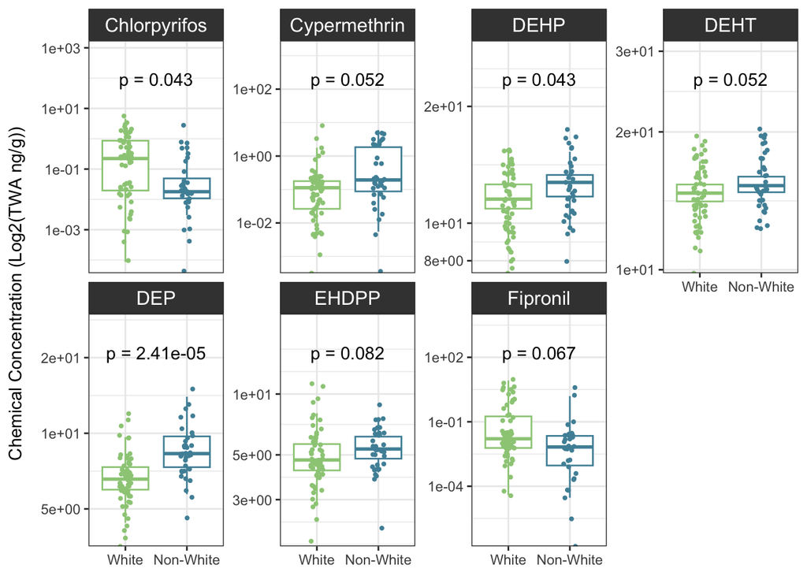

```r
# Select chemicals that have padj < 0.1 for race
race_chems <- race_wilcoxres %>% filter(padj_race < 0.1) %>% pull(class_chemical)

# Prepare p-values
race_chems_pvals <- race_wilcoxres %>%
  filter(padj_race < 0.1) %>%
  mutate(padj_race = ifelse(padj_race > 0.001, round(padj_race, digits = 3), format(padj_race, digits = 3))) %>%
  mutate(padj_race = paste("p = ", padj_race, sep = ""))

# Prepare y values for graphing the p-values. Note that this had to be through trial and error of different expansion factors
# Due to different scales and variability within each chemical
race_chems_heights <- chem_demo %>%
  select(all_of(race_chems)) %>%
  summarise(across(everything(), max)) %>%
  t() %>% as.data.frame() %>%
  rownames_to_column("class_chemical") %>%
  rename("max_y" = "V1") %>%
  mutate(pval_y = ifelse(class_chemical %in% c("Pest_Chlorpyrifos", "Pest_Cypermethrin", "Pest_Fipronil"), max_y*20, max_y*1.5))

# Merge together pvalues and heights
race_chems_pval_labels <- left_join(race_chems_pvals, race_chems_heights, by = "class_chemical") %>%
  separate(class_chemical, into = c(NA, "chemical"))

# Prepare data frame for graphing
chem_demo_racegraphing <- chem_demo %>%
  select(c(all_of(race_chems), race_forstats, S_ID)) %>%
  pivot_longer(-c(race_forstats, S_ID), names_to = "class_chemical", values_to = "Value") %>%
  left_join(chemical_key, by = "class_chemical") %>%
  mutate(chemical = gsub("cypermethrin", "Cypermethrin", chemical)) %>%
  mutate(race_forstats = fct_relevel(factor(race_forstats), c("White", "Non-White")))

chem_demo_race_graph <- ggplot() +
  geom_boxplot(chem_demo_racegraphing,
               mapping = aes(x = race_forstats, y = Value, color = race_forstats), outlier.shape = NA) +
  geom_jitter(chem_demo_racegraphing,
              mapping = aes(x = race_forstats, y = Value, color = race_forstats), size = 0.75, width = 0.1, height = 0.1) +
  scale_color_manual(values = c("#9CCB86", "#4F90A6")) +
  scale_y_log10(expand = expansion(mult = c(0, 0.2)), labels = function(x) format(x, scientific = TRUE)) +
  theme(axis.title.x = element_blank(),
        axis.title.y = element_text(margin = margin(t = 0, r = 10, b = 0, l = 0)),
        legend.position = "none",
        strip.background = element_rect(fill ="gray25"),
        strip.text = element_text(color = "white", size = 12)) +
  labs(y = "Chemical Concentration (Log2(TWA ng/g))") +
  geom_text(data = race_chems_pval_labels, mapping = aes(x = 1.5, y = pval_y, label = padj_race)) +
  facet_wrap(~chemical, nrow = 2, scales = "free_y")

chem_demo_race_graph
```

```r
pdf("3_OutputFigs/Chemical_Race_SigPanel.pdf",
    width = 8, height = 4.5)
chem_demo_race_graph
invisible(dev.off())
```

## 3.2 All Variables Together - ANCOVA

```r
# Make cleaned data frame for ANCOVA
chem_demo_forancova <- chem_demo %>%
  column_to_rownames("S_ID") %>%
  select(-c(child_age_months, child_gest_age_birth,
            child_sex, pc_sex, pc_gender, pc_race_cleaned, relationship, yrs_with_part))

# Create empty data frame
ANCOVAres_chem = data.frame("Variable" = c("(Intercept)", "mat_age_birth", "race_forstats", "pc_latino_hispanic", "pc_ed", "Residuals"))

# Perform ANCOVA over all columns
for (i in 1:length(endpoints)) {

  fit = aov(as.formula(paste0(names(chem_demo_forancova)[i], "~ mat_age_birth + race_forstats + pc_latino_hispanic +  pc_ed", sep = "")), chem_demo_forancova)
  res <- data.frame(Anova(fit, type="III"))
  res <- subset(res, select = Pr..F.)
  names(res)[names(res) == 'Pr..F.'] <- noquote(paste0(names(chem_demo_forancova[i])))
  res <- res %>%
  rownames_to_column("Variable")

  ANCOVAres_chem <- left_join(ANCOVAres_chem, res, by = "Variable")
}

# Clean data frame
ANCOVAres_chem <- ANCOVAres_chem %>%
  column_to_rownames("Variable") %>%
  t() %>% as.data.frame() %>%
  select(-c("(Intercept)", "Residuals")) %>%
  mutate(across(everything(), \(x) round(x, 6))) %>%
  rownames_to_column("class_chemical")

# Create adjusted p-values
ANCOVAres_chem_adj <- ANCOVAres_chem %>%
  mutate(across(!class_chemical, \(x) p.adjust(x, "BH"))) %>%
  mutate(across(!class_chemical, \(x) round(x, 6))) %>%
  rename_with( ~ paste0(.x, "_adj")) %>%
  rename("class_chemical" = "class_chemical_adj")

# Merge and clean data frames
ANCOVAres_cleaned <- ANCOVAres_chem %>%
  left_join(ANCOVAres_chem_adj, by = "class_chemical") %>%
  left_join(chemical_key, by = "class_chemical") %>%
  relocate(c(class, chemical), .before = "mat_age_birth")

# Save results
write.xlsx(ANCOVAres_cleaned, "2_OutputTables/ANCOVA_Res.xlsx")
```

# 4 Chemical exposure + social stress

## 4.1 K-means clustering

Choose number of clusters:

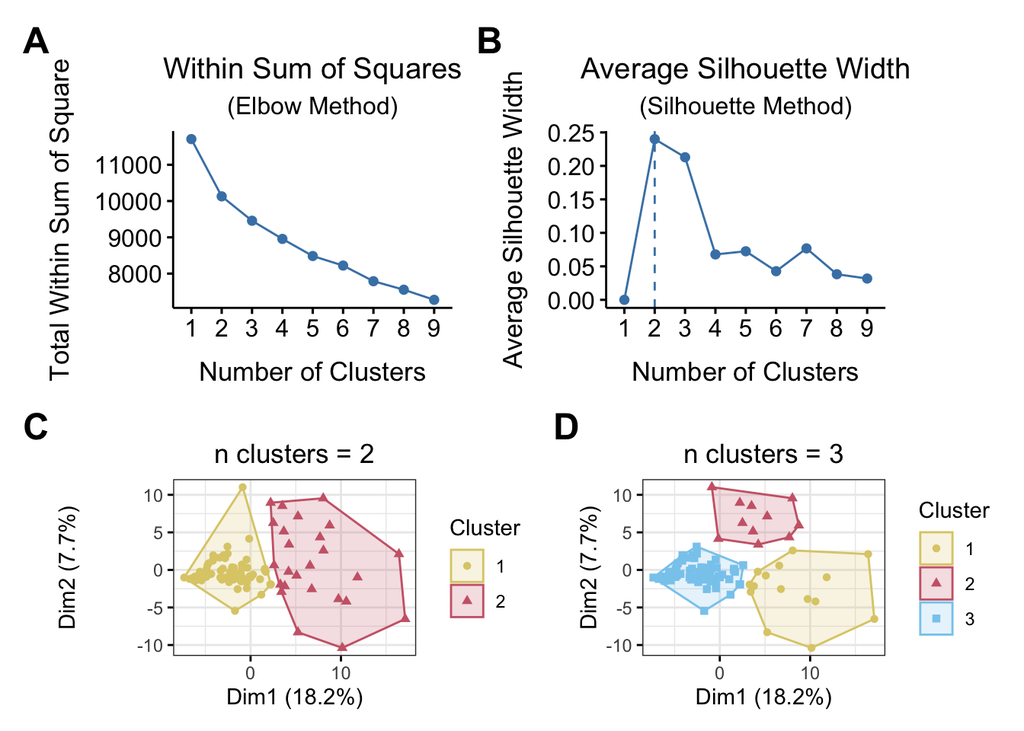

```r
# Set seed
set.seed(1114)

# Prepare data - resuming workflow after data are scaled and outlier is removed
ss_data_indiv_sc <- ss_data %>%
  column_to_rownames("S_ID") %>%
  scale() %>% data.frame() %>%
  rownames_to_column("S_ID") %>%
  filter(S_ID != "1169") %>%
  column_to_rownames("S_ID") %>%
  select(-c(cpsq_mean:crs_mean)) %>%
  select_if(~ !any(is.na(.)))

# Visualizations for optimal number of clusters. k.max must be at most, one less than the smaller of the 2 dimensions of the data frame or it will bug.

# WSS
wss <- fviz_nbclust(ss_data_indiv_sc, method = "wss", kmeans, k.max = 9) +
  ggtitle("Within Sum of Squares") +
  labs(subtitle = "(Elbow Method)",
       x = "Number of Clusters") +
  theme(plot.title = element_text(hjust = 0.5),
        plot.subtitle = element_text(hjust = 0.5),
        axis.title.x = element_text(margin = ggplot2::margin(t = 10), size = 13),
        axis.title.y = element_text(margin = ggplot2::margin(r = 10), size = 13))

# Silhouette
silhouette <- fviz_nbclust(ss_data_indiv_sc, method = "silhouette", kmeans, k.max = 9) +
  ggtitle("Average Silhouette Width") +
  labs(subtitle = "(Silhouette Method)",
       x = "Number of Clusters",
       y = "Average Silhouette Width") +
  theme(plot.title = element_text(hjust = 0.5),
        plot.subtitle = element_text(hjust = 0.5),
        axis.title.x = element_text(margin = ggplot2::margin(t = 10), size = 13),
        axis.title.y = element_text(margin = ggplot2::margin(r = 10), size = 13))

# Cluster plots
cluster_plots = list()
for (i in 2:3){
    Cluster_k <- kmeans(ss_data_indiv_sc, centers = i, nstart = 25)
    cluster_plots[[i]] <- fviz_cluster(Cluster_k,
                                       data = ss_data_indiv_sc,
                                       geom = "point",
                                       ggtheme = theme_bw(),
                                       show.clust.cent = FALSE) +
      scale_colour_manual(values = c("#DDCC77", "#CC6677", "#88CCEE", "#117733", "#332288")) +
      scale_fill_manual(values = c("#DDCC77", "#CC6677", "#88CCEE", "#117733", "#332288")) +
      ggtitle(paste0("n clusters = ",i)) +
      guides(fill = guide_legend(title = "Cluster"),
             color = guide_legend(title = "Cluster"),
             shape = guide_legend(title = "Cluster")) +
      theme(plot.title = element_text(hjust = 0.5))
}

# Make final figure
ss_clusterselect <- (wss + silhouette)/(cluster_plots[[2]] + cluster_plots[[3]]) +
  plot_annotation(tag_levels = 'A') &
  theme(plot.tag = element_text(face = "bold", size = 18))

pdf("3_OutputFigs/KmeansClustersSelection.pdf",
    width = 11, height = 10)
ss_clusterselect
invisible(dev.off())

ss_clusterselect
```

## 4.2 Significant differences in individual chemicals across social stress clusters

Assign clusters and determine if there are significant differences in any of the chemical exposures by cluster:

```r
# Set seed
set.seed(1114)

# Extract cluster assignments
cluster_k3 <- kmeans(ss_data_indiv_sc, centers = 3, nstart = 25)
cluster_k3 <- as.data.frame(cluster_k3$cluster) %>%
  clean_names() %>%
  rownames_to_column("S_ID") %>%
  rename("cluster_k3" = "cluster_k3_cluster") %>%
  mutate(across(cluster_k3, \(x) as.character(x)))

# Add social stressor cluster into chemical exposure data frame. Recode SS cluster numbers so they match plot in supplement.
wb_log2_sscluster <- wb_log2 %>%
  left_join(cluster_k3, by = "S_ID") %>%
  filter(S_ID != "1169") %>%
  column_to_rownames("S_ID")

wb_log2_sscluster %>% group_by(cluster_k3) %>%
  summarise(n = n())
```

```
## # A tibble: 3 × 2
##   cluster_k3     n
##   <chr>      <int>
## 1 1             15
## 2 2             11
## 3 3             70
```

```r
# Run Kruskal-Wallis by group for all variables
cluster_kruskal_res <- wb_log2_sscluster %>%
  pivot_longer(!cluster_k3, names_to = "Variable", values_to = "Value") %>%
  group_by(Variable) %>%
  do(tidy(kruskal.test(x = .$Value, g = .$cluster_k3))) %>%
  dplyr::select(c(Variable, p.value))

cluster_kruskal_res$padj = p.adjust(cluster_kruskal_res$p.value, method = "BH")
```

Perform Dunn’s posthoc:

```r
# Define groups for Dunn test
groups <- c("1", "2", "3")

endpoints <- colnames(wb_log2_sscluster %>% select(c(alkylOPE_2IPPDPP:Phthal_TOTM)))

# Vectorized Dunn's test (could not get my normal lappy to work)
dunn_testv <- Vectorize(dunn_test, vectorize.args="formula", SIMPLIFY=F)
reformulatev <- Vectorize(reformulate, vectorize.args="response")

chem_cluster_dunn_res <- dunn_testv(wb_log2_sscluster, reformulatev("cluster_k3", endpoints), p.adjust.method="BH")
chem_cluster_dunn_res <- do.call(rbind, chem_cluster_dunn_res)

# Create trimmed dunn res for only those chemicals with significance in Kruskal-Wallis test
chem_cluster_sig_chems <- cluster_kruskal_res %>%
  filter(p.value < 0.1) %>%
  pull(Variable)

chem_cluster_dunn_res_trimmed <- chem_cluster_dunn_res %>%
  filter(.y. %in% chem_cluster_sig_chems) %>%
  filter(p.adj < 0.1)
```

Graph isodecyl diphenyl phosphate (isodecylIPP), which had the only p-value that remained significant after p-value adjustment.

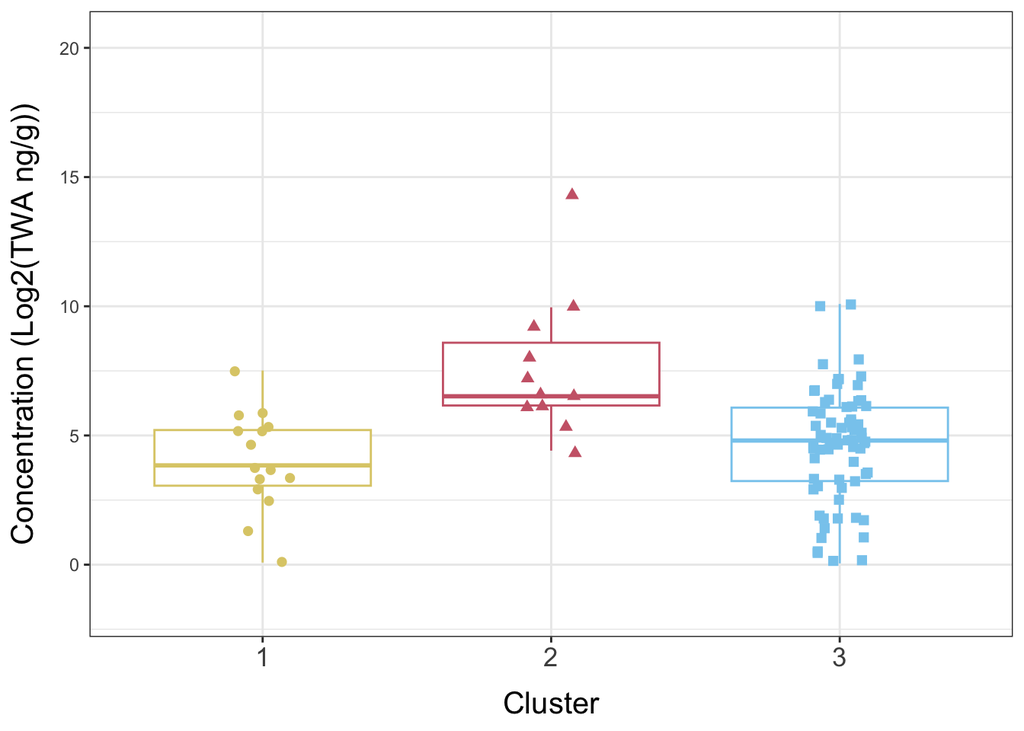

```r
# IDP graph
cluster_ss_idp <- ggplot(wb_log2_sscluster, aes(x = cluster_k3, y = OPE_isodecylPP,
                                                color = cluster_k3, shape = cluster_k3)) +
  geom_boxplot(outlier.shape = NA) +
  geom_jitter(size = 2, width = 0.1, height=0.1) +
  scale_color_manual(values = c("#DDCC77", "#CC6677", "#88CCEE")) +
  scale_shape_manual(values = c(16, 17, 15)) +
  theme(legend.position = "none") +
  labs(y = "Concentration (Log2(TWA ng/g))", x = "Cluster") +
  scale_y_continuous(expand = expansion(mult = c(0.2, 0.5))) +
   theme(axis.title.x = element_text(margin = ggplot2::margin(t = 10), size = 15),
         axis.title.y = element_text(margin = ggplot2::margin(r = 10), size = 15),
         axis.text.x = element_text(size = 13))

pdf("3_OutputFigs/SS_Cluster_isodecylIPP.pdf",
    width = 3, height = 4)
cluster_ss_idp
invisible(dev.off())

cluster_ss_idp
```

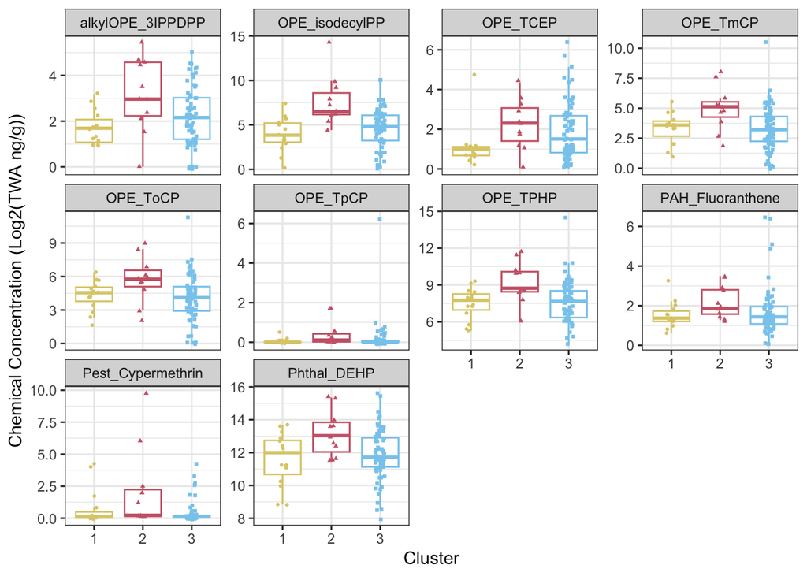

```r
# Select chemicals with p < 0.1
chems_for_panel <- cluster_kruskal_res %>%
  filter(p.value < 0.05) %>%
  pull("Variable")

# Pivot data longer
wb_log2_sscluster_forgraphing <- wb_log2_sscluster %>%
  rownames_to_column("S_ID") %>%
  filter(S_ID != "1169") %>%
  column_to_rownames("S_ID") %>%
  select(c(all_of(chems_for_panel), cluster_k3)) %>%
  pivot_longer(!cluster_k3, names_to = "Chemical", values_to = "Value")

cluster_ss_chem_panel <- ggplot(wb_log2_sscluster_forgraphing, aes(x = cluster_k3, y = Value,
                                                                   color = cluster_k3, shape = cluster_k3)) +
  geom_boxplot(outlier.shape = NA) +
  geom_jitter(size = 0.75, width=0.1, height=0.1) +
  scale_color_manual(values = c("#DDCC77", "#CC6677", "#88CCEE")) +
  scale_shape_manual(values = c(16, 17, 15)) +
  theme(legend.position = "none") +
  labs(y = "Chemical Concentration (Log2(TWA ng/g))", x = "Cluster") +
  facet_wrap(~Chemical, nrow = 3, scales = "free_y")

cluster_ss_chem_panel
```

Write out simplified results table for the main figure in the manuscript:

```r
# Clean data
cluster_kruskal_res_cleaned <- cluster_kruskal_res %>%
  select(-padj) %>%
  filter(p.value < 0.05) %>%
  rename("class_chemical" = "Variable") %>%
  left_join(chemical_key, by = "class_chemical") %>%
  arrange(p.value) %>%
  mutate(p.value = round(p.value, digits = 3))

# Write out data
write.xlsx(cluster_kruskal_res_cleaned, "2_OutputTables/Cluster_SS_Chem_KruskalRes_Cleaned.xlsx")
```

Write out more complete results table for supplement:

```r
# Clean pairwise data and pivot wider
chem_cluster_dunn_res_trimmed_clean <- chem_cluster_dunn_res %>%
  filter(.y. %in% chems_for_panel) %>%
  rename("class_chemical" = ".y.") %>%
  unite(comparison, group1, group2, sep = " vs. ") %>%
  mutate(comparison = paste("Cluster", comparison, sep = " ")) %>%
  select(c(class_chemical, comparison, p.adj)) %>%
  pivot_wider(id_cols = class_chemical, names_from = comparison, values_from = p.adj) %>%
  left_join(cluster_kruskal_res_cleaned, by = "class_chemical") %>%
  select(-class_chemical) %>%
  relocate(c(chemical, class, p.value), .before = "Cluster 1 vs. 2") %>%
  mutate(across(where(is.numeric), ~ round(.x, digits = 3))) %>%
  arrange(p.value)

# Write out results
write.xlsx(chem_cluster_dunn_res_trimmed_clean , "2_OutputTables/Cluster_SS_Chem_KruskalRes_WithDunns.xlsx")
```

## 4.3 Significant difference in total chemical burden across social stress clusters

```r
# Min-max scale the chemical data
wb_log2_minmax <- wb_log2 %>%
  filter(S_ID != "1169") %>%
  column_to_rownames("S_ID") %>%
  mutate(across(where(is.numeric), \(x) (x-min(x))/(max(x)-min(x)))) %>%
  mutate(chemsum=rowSums(.)) %>%
  select(chemsum) %>%
  rownames_to_column("S_ID") %>%
  left_join(cluster_k3, by = "S_ID")

# Run Kruskal-Wallis test
kruskal.test(x = wb_log2_minmax$chemsum, g = wb_log2_minmax$cluster_k3)
```

```
##
##  Kruskal-Wallis rank sum test
##
## data:  wb_log2_minmax$chemsum and wb_log2_minmax$cluster_k3
## Kruskal-Wallis chi-squared = 4.8176, df = 2, p-value = 0.08992
```

```r
# Run Dunn's test
dunn_test(wb_log2_minmax, chemsum ~ cluster_k3, p.adjust.method = "BH")
```

```
## # A tibble: 3 × 9
##   .y.     group1 group2    n1    n2 statistic      p  p.adj p.adj.signif
## * <chr>   <chr>  <chr>  <int> <int>     <dbl>  <dbl>  <dbl> <chr>
## 1 chemsum 1      2         15    11      2.18 0.0296 0.0887 ns
## 2 chemsum 1      3         15    70      1.05 0.293  0.293  ns
## 3 chemsum 2      3         11    70     -1.74 0.0817 0.123  ns
```

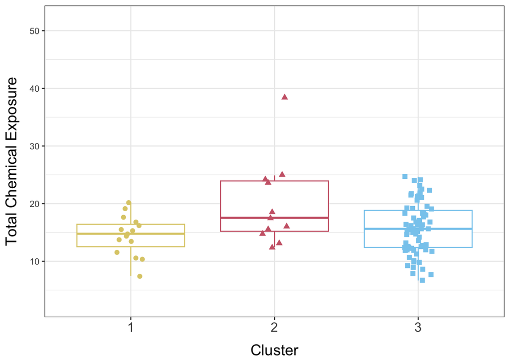

```r
# Make graph
chem_sum_graph <- ggplot(wb_log2_minmax %>%
                           mutate(cluster_k3 = as.character(cluster_k3))
                           , aes(x = cluster_k3, y = chemsum, color = cluster_k3, shape = cluster_k3)) +
  geom_boxplot(outlier.shape = NA) +
  geom_jitter(size = 2, width = 0.1, height=0.1) +
  scale_color_manual(values = c("#DDCC77", "#CC6677", "#88CCEE")) +
  scale_shape_manual(values = c(16, 17, 15)) +
  theme(legend.position = "none") +
  labs(y = "Total Chemical Exposure", x = "Cluster") +
  scale_y_continuous(expand = expansion(mult = c(0.2, 0.5))) +
   theme(axis.title.x = element_text(margin = ggplot2::margin(t = 10), size = 15),
         axis.title.y = element_text(margin = ggplot2::margin(r = 10), size = 15),
         axis.text.x = element_text(size = 13))

pdf("3_OutputFigs/ChemSum_BySSCluster.pdf",
    width = 3, height = 4)
chem_sum_graph
invisible(dev.off())

chem_sum_graph
```

## 4.4 Characteristics of Clusters

Are there significant differences in the mean of all social stressor variables (questions) across clusters?

```r
# Make data frame for stats
ss_for_kruskal <- ss_data %>%
  filter(S_ID != "1169") %>%
  select(-c(cpsq_mean:crs_mean)) %>%
  mutate(mean_ss = rowMeans(across(where(is.numeric)))) %>%
  left_join(cluster_k3, by = "S_ID") %>%
  mutate(cluster_k3 = as.character(cluster_k3))

# Calculate means
ss_for_kruskal %>%
  group_by(cluster_k3) %>%
  summarise(mean = mean(mean_ss))
```

```
## # A tibble: 3 × 2
##   cluster_k3  mean
##   <chr>      <dbl>
## 1 1          1.33
## 2 2          1.29
## 3 3          0.928
```

```r
# Run tests
kruskal.test(ss_for_kruskal$mean_ss, ss_for_kruskal$cluster_k3)
```

```
##
##  Kruskal-Wallis rank sum test
##
## data:  ss_for_kruskal$mean_ss and ss_for_kruskal$cluster_k3
## Kruskal-Wallis chi-squared = 40.627, df = 2, p-value = 1.506e-09
```

```r
dunn_test(ss_for_kruskal, mean_ss ~ cluster_k3, p.adjust.method = "BH")
```

```
## # A tibble: 3 × 9
##   .y.     group1 group2    n1    n2 statistic           p     p.adj p.adj.signif
## * <chr>   <chr>  <chr>  <int> <int>     <dbl>       <dbl>     <dbl> <chr>
## 1 mean_ss 1      2         15    11     0.106 0.915         9.15e-1 ns
## 2 mean_ss 1      3         15    70    -5.08  0.000000374   1.12e-6 ****
## 3 mean_ss 2      3         11    70    -4.59  0.00000448    6.71e-6 ****
```

Are there significant differences in the mean of all social stressor summary variables across clusters?

```r
# Make data frame for stats
ss_for_kruskal_summvars <- ss_data %>%
  filter(S_ID != "1169") %>%
  select(c(S_ID, hhi_income2needs:crs_mean)) %>%
  mutate(mean_ss = rowMeans(across(where(is.numeric)))) %>%
  left_join(cluster_k3, by = "S_ID") %>%
  mutate(cluster_k3 = as.character(cluster_k3))

# Run tests
kruskal.test(ss_for_kruskal_summvars$mean_ss, ss_for_kruskal$cluster_k3)
```

```
##
##  Kruskal-Wallis rank sum test
##
## data:  ss_for_kruskal_summvars$mean_ss and ss_for_kruskal$cluster_k3
## Kruskal-Wallis chi-squared = 20.184, df = 2, p-value = 4.141e-05
```

```r
dunn_test(ss_for_kruskal_summvars, mean_ss ~ cluster_k3, p.adjust.method = "BH")
```

```
## # A tibble: 3 × 9
##   .y.     group1 group2    n1    n2 statistic        p    p.adj p.adj.signif
## * <chr>   <chr>  <chr>  <int> <int>     <dbl>    <dbl>    <dbl> <chr>
## 1 mean_ss 1      2         15    11      1.04 0.296    0.296    ns
## 2 mean_ss 1      3         15    70     -2.91 0.00360  0.00541  **
## 3 mean_ss 2      3         11    70     -3.83 0.000127 0.000382 ***
```

Are there significant differences in specific social stressor summary variables across clusters?

```r
# Prepare data frame
ss_for_kruskal_summvars_all <- ss_data %>%
  filter(S_ID != "1169") %>%
  select(c(S_ID, hhi_income2needs:crs_mean)) %>%
  left_join(cluster_k3, by = "S_ID") %>%
  mutate(cluster_k3 = as.character(cluster_k3)) %>%
  column_to_rownames("S_ID")

# Run Kruskal-Wallis test
cluster_kruskal_res_summvars <- ss_for_kruskal_summvars_all %>%
  pivot_longer(!cluster_k3, names_to = "Variable", values_to = "Value") %>%
  group_by(Variable) %>%
  do(tidy(kruskal.test(x = .$Value, g = .$cluster_k3))) %>%
  dplyr::select(c(Variable, p.value))

cluster_kruskal_res_summvars$padj = p.adjust(cluster_kruskal_res_summvars$p.value, method = "BH")

# Run Dunn's test
endpoints <- colnames(ss_for_kruskal_summvars_all %>% select(-cluster_k3))

dunn_testv <- Vectorize(dunn_test, vectorize.args="formula", SIMPLIFY=F)
reformulatev <- Vectorize(reformulate, vectorize.args="response")

cluster_dunn_res_summvars <- dunn_testv(ss_for_kruskal_summvars_all, reformulatev("cluster_k3", endpoints), p.adjust.method="BH")

cluster_dunn_res_summvars <- do.call(rbind, cluster_dunn_res_summvars)
```

Make heatmap of any summary variables with a significant pairwise comparison:

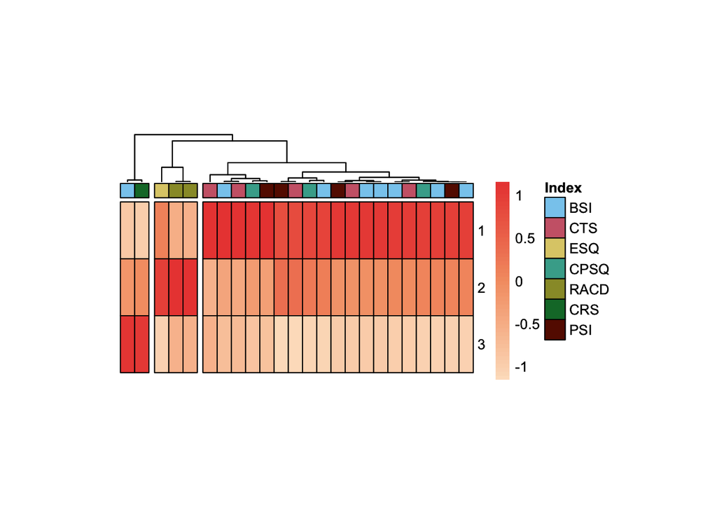

```r
# Filter for significant variables
ss_vars_forheatmap <- cluster_dunn_res_summvars %>%
  filter(p < 0.05) %>%
  pull(.y.)

# Calculate means of summary variables by cluster
ss_cluster_forheatmap <- ss_for_kruskal_summvars_all %>%
  group_by(cluster_k3) %>%
  summarise(across(everything(), \(x) mean(x))) %>%
  select(c(cluster_k3, all_of(ss_vars_forheatmap))) %>%
  column_to_rownames("cluster_k3") %>%
  as.matrix()

# Make heatmap key and colors
ss_heatmap_key <- ss_cluster_forheatmap %>%
  t() %>% as.data.frame() %>%
  rownames_to_column("variable") %>%
  separate(variable, into = c("Index", "variable1", "variable2"), remove = FALSE) %>%
  column_to_rownames("variable") %>%
  select(Index) %>%
  mutate(Index = toupper(Index))
ss_colors = list("Index" = c("BSI" = "#88CCEE", "CTS" = "#CC6677", "ESQ" = "#DDCC77", "CPSQ" = "#44AA99", "RACD" = "#999933", "CRS" = "#117733", "PSI" = "#661100"))

ss_cluster_heatmap <- pheatmap(ss_cluster_forheatmap,
         annotation_col = ss_heatmap_key,
         annotation_colors = ss_colors,
         annotation_names_col = FALSE,
         cutree_cols = 3,
         show_colnames = FALSE,
         cluster_rows = FALSE,
         scale = 'column',
         border_color = "black",
         treeheight_col = 30,
         cellwidth = 10,
         cellheight = 40,
         color = colorRampPalette(c("#FDE0C5", "#F59E72", "#EB4A40"))(50))

pdf("3_OutputFigs/SS_Cluster_Heatmap.pdf",
    width = 10, height = 5)
ss_cluster_heatmap
invisible(dev.off())

ss_cluster_heatmap
```

Heatmap with individual level variables for the supplement:

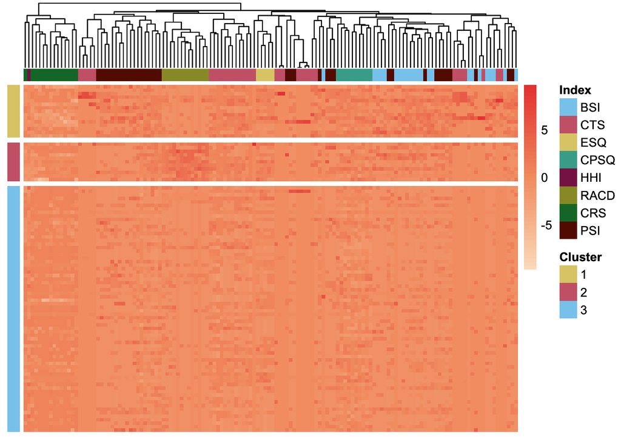

```r
# Prepare data frame for heatmap
ss_indiv_for_heatmap <- ss_for_kruskal %>%
  column_to_rownames("S_ID") %>%
  arrange(cluster_k3) %>%
  select(-cluster_k3) %>%
  select(all_of(names(ss_data_indiv_sc))) %>%
  as.matrix()

# Add an index value into the dataframe so we can add splits between groups in heatmap
cluster_k3 <- cluster_k3 %>%
  arrange(cluster_k3)

cluster_k3$index <- 1:nrow(cluster_k3)

# Make lists of where breaks should be placed in the heatmap to separate clusters of samples
seprows <- cluster_k3 %>% group_by(cluster_k3) %>% slice_max(n = 1, order_by = index)
seprows <- sort(seprows$index)

# Prepare annotation data frames
cluster_anno <- ss_for_kruskal %>%
  select(c(S_ID, cluster_k3)) %>%
  column_to_rownames("S_ID") %>%
  rename("Cluster" = "cluster_k3")

variable_anno <- ss_indiv_for_heatmap %>%
  t() %>% as.data.frame() %>%
  rownames_to_column("variable") %>%
  separate(variable, into = c("Index", "variable1", "variable2"), remove = FALSE) %>%
  column_to_rownames("variable") %>%
  select(Index) %>%
  mutate(Index = toupper(Index)) %>%
  mutate(Index = gsub("[[:digit:]]", "", Index)) %>%
  mutate(Index = gsub("R$", "", Index)) %>%
  mutate(Index = gsub("A$", "", Index)) %>%
  mutate(Index = gsub("B$", "", Index)) %>%
  mutate(Index = gsub("C$", "", Index))
# Prepare color key
colors_indiv = list("Index" = c("BSI" = "#88CCEE", "CTS" = "#CC6677", "ESQ" = "#DDCC77", "CPSQ" = "#44AA99",
                                "HHI" = "#882255", "RACD" = "#999933", "CRS" = "#117733", "PSI" = "#661100"),
                    "Cluster" = c("1" = "#DDCC77", "2" = "#CC6677", "3" = "#88CCEE"))



# Make heatmap
ss_cluster_heatmap_indiv <- pheatmap(ss_indiv_for_heatmap,
         annotation_col = variable_anno,
         annotation_row = cluster_anno,
         annotation_colors = colors_indiv,
         annotation_names_col = FALSE,
         annotation_names_row = FALSE,
         cluster_rows = FALSE,
         show_colnames = FALSE,
         show_rownames = FALSE,
         scale = 'column',
         border_color = "black",
         gaps_row = seprows,
         color = colorRampPalette(c("#FDE0C5", "#F59E72", "#EB4A40"))(50))

pdf("3_OutputFigs/SS_Cluster_Heatmap_Indiv.pdf",
    width = 10, height = 5)
ss_cluster_heatmap_indiv
invisible(dev.off())

ss_cluster_heatmap_indiv
```

Demographic differences between clusters:

```r
# Merge data
chem_demo_fortable <- left_join(chem_demo, cluster_k3, by = "S_ID") %>%
  filter(S_ID != "1169") %>%
  mutate(race_forstats = case_when(pc_race_cleaned == "White" ~ "White",
                                   .default = "Non-White"))

# Create function for custom table so that Mean (SD) is shown for continuous variables
my.render.cont <- function(x) {
  with(stats.apply.rounding(stats.default(x), digits=2), c("",
                                                           "Mean (SD)"=sprintf("%s (&plusmn; %s)", MEAN, SD)))
}

# Make table
table1(~ mat_age_birth + race_forstats + pc_latino_hispanic + pc_ed | cluster_k3,
       data = chem_demo_fortable,
       render.continuous = my.render.cont)
```

|  | 1 (N=15) | 2 (N=11) | 3 (N=70) | Overall (N=96) |
| --- | --- | --- | --- | --- |
| mat_age_birth |  |  |  |  |
| Mean (SD) | 28 (± 4.9) | 30 (± 6.2) | 32 (± 5.4) | 31 (± 5.5) |
| race_forstats |  |  |  |  |
| Non-White | 6 (40.0%) | 7 (63.6%) | 21 (30.0%) | 34 (35.4%) |
| White | 9 (60.0%) | 4 (36.4%) | 49 (70.0%) | 62 (64.6%) |
| pc_latino_hispanic |  |  |  |  |
| No | 11 (73.3%) | 8 (72.7%) | 63 (90.0%) | 82 (85.4%) |
| Yes | 4 (26.7%) | 3 (27.3%) | 7 (10.0%) | 14 (14.6%) |
| pc_ed |  |  |  |  |
| Four-Year Degree | 5 (33.3%) | 4 (36.4%) | 26 (37.1%) | 35 (36.5%) |
| High School or GED | 7 (46.7%) | 4 (36.4%) | 17 (24.3%) | 28 (29.2%) |
| Master's Degree | 1 (6.7%) | 2 (18.2%) | 12 (17.1%) | 15 (15.6%) |
| Professional Degree or PhD | 2 (13.3%) | 1 (9.1%) | 9 (12.9%) | 12 (12.5%) |
| Associate Degree | 0 (0%) | 0 (0%) | 6 (8.6%) | 6 (6.3%) |

```r
# Run Fisher Test
fisher.test(table(chem_demo_fortable$race_forstats, chem_demo_fortable$cluster_k3))
```

```
##
##  Fisher's Exact Test for Count Data
##
## data:  table(chem_demo_fortable$race_forstats, chem_demo_fortable$cluster_k3)
## p-value = 0.09161
## alternative hypothesis: two.sided
```